# **Experiment 2**

Pratham Goyal A2345924079 4CSE-2eve

# **Importing Necessary Libraries**

```python
import numpy as np
import pandas as pd
```

# **Loading the Birds Dataset**

There are many kinds of birds: pigeons, ducks, ostriches, penguins… Some are good at flying, others can't fly but run fast. Some swim under water, others wading in shallow pool.

According to their living environments and living habits, birds are classified into different ecological groups. There are 6 ecological groups of birds:

- Swimming Birds (SW)
- Wading Birds (W)
- Terrestrial Birds (T)
- Raptors (R)
- Scansorial Birds (P)
- Singing Birds (SO)

Apparently, birds belong to different ecological groups have different appearances: **flying birds have strong wings and wading birds have long legs**. Their living habits are somewhat reflected in their bones' shapes. As data scientists we may think of examining the underlying relationship between sizes of bones and ecological groups, and recognising birds' ecological groups by their bones' shapes.

**Content**

There are 420 birds contained in this dataset. Each bird is represented by 10 measurements (features):

- Length and Diameter of Humerus
- Length and Diameter of Ulna
- Length and Diameter of Femur
- Length and Diameter of Tibiotarsus
- Length and Diameter of Tarsometatarsus

```python
bird_data = pd.read_csv('/kaggle/input/bird-file/bird.csv', delimiter = ',')
bird_data.head(5)
```

|  | id | huml | humw | ulnal | ulnaw | feml | femw | tibl | tibw | tarl | tarw | type |
| --- | --- | --- | --- | --- | --- | --- | --- | --- | --- | --- | --- | --- |
| 0 | 0 | 80.78 | 6.68 | 72.01 | 4.88 | 41.81 | 3.70 | 5.50 | 4.03 | 38.70 | 3.84 | SW |
| 1 | 1 | 88.91 | 6.63 | 80.53 | 5.59 | 47.04 | 4.30 | 80.22 | 4.51 | 41.50 | 4.01 | SW |
| 2 | 2 | 79.97 | 6.37 | 69.26 | 5.28 | 43.07 | 3.90 | 75.35 | 4.04 | 38.31 | 3.34 | SW |
| 3 | 3 | 77.65 | 5.70 | 65.76 | 4.77 | 40.04 | 3.52 | 69.17 | 3.40 | 35.78 | 3.41 | SW |
| 4 | 4 | 62.80 | 4.84 | 52.09 | 3.73 | 33.95 | 2.72 | 56.27 | 2.96 | 31.88 | 3.13 | SW |

# **Accessing the Column Names in the Dataset**

```python
bird_data.columns
```

```
Index(['id', 'huml', 'humw', 'ulnal', 'ulnaw', 'feml', 'femw', 'tibl', 'tibw',
       'tarl', 'tarw', 'type'],
      dtype='object')
```

```python
bird_data = bird_data.set_index('id')
bird_data.head()
```

| id | huml | humw | ulnal | ulnaw | feml | femw | tibl | tibw | tarl | tarw | type |
| --- | --- | --- | --- | --- | --- | --- | --- | --- | --- | --- | --- |
| 0 | 80.78 | 6.68 | 72.01 | 4.88 | 41.81 | 3.70 | 5.50 | 4.03 | 38.70 | 3.84 | SW |
| 1 | 88.91 | 6.63 | 80.53 | 5.59 | 47.04 | 4.30 | 80.22 | 4.51 | 41.50 | 4.01 | SW |
| 2 | 79.97 | 6.37 | 69.26 | 5.28 | 43.07 | 3.90 | 75.35 | 4.04 | 38.31 | 3.34 | SW |
| 3 | 77.65 | 5.70 | 65.76 | 4.77 | 40.04 | 3.52 | 69.17 | 3.40 | 35.78 | 3.41 | SW |
| 4 | 62.80 | 4.84 | 52.09 | 3.73 | 33.95 | 2.72 | 56.27 | 2.96 | 31.88 | 3.13 | SW |

# **Finding the Shape of the Dataset**

```python
bird_data.shape
```

```
(420, 11)
```

```python
bird_data.info()
```

```
<class 'pandas.core.frame.DataFrame'>
Index: 420 entries, 0 to 419
Data columns (total 11 columns):
 #   Column  Non-Null Count  Dtype
---  ------  --------------  -----
 0   huml    419 non-null    float64
 1   humw    419 non-null    float64
 2   ulnal   417 non-null    float64
 3   ulnaw   418 non-null    float64
 4   feml    418 non-null    float64
 5   femw    419 non-null    float64
 6   tibl    418 non-null    float64
 7   tibw    419 non-null    float64
 8   tarl    419 non-null    float64
 9   tarw    419 non-null    float64
 10  type    420 non-null    object
dtypes: float64(10), object(1)
memory usage: 39.4+ KB
```

### **Checking Missing Values**

```python
bird_data.isna().sum()
```

```
huml     1
humw     1
ulnal    3
ulnaw    2
feml     2
femw     1
tibl     2
tibw     1
tarl     1
tarw     1
type     0
dtype: int64
```

```python
bird_data.dropna(how='any', inplace=True)
```

```python
bird_data.isna().sum()
```

```
huml     0
humw     0
ulnal    0
ulnaw    0
feml     0
femw     0
tibl     0
tibw     0
tarl     0
tarw     0
type     0
dtype: int64
```

```python
bird_data.shape
```

```
(413, 11)
```

# **Unique Values in the Data**

```python
bird_data.nunique()
```

```
huml     403
humw     319
ulnal    394
ulnaw    305
feml     397
femw     287
tibl     401
tibw     283
tarl     403
tarw     277
type       6
dtype: int64
```

```python
bird_data['type'].unique()
```

```
array(['SW', 'W', 'T', 'R', 'P', 'SO'], dtype=object)
```

# **Label Encoding of Categorical Variables**

Label Encoding means converting categorical features into numerical values. So that they can be fitted by machine learning models which only take numerical data.

**Example:** Suppose we have a column Height in some dataset that has elements as Tall, Medium, and short. To convert this categorical column into a numerical column we will apply label encoding to this column. After applying label encoding, the Height column is converted into a numerical column having elements 0,1, and 2 where 0 is the label for tall, 1 is the label for medium, and 2 is the label for short height.

```python
from sklearn.preprocessing import LabelEncoder
le = LabelEncoder()
bird_data[['type']] = bird_data[['type']].apply(le.fit_transform)
```

```python
bird_data.head()
```

| id | huml | humw | ulnal | ulnaw | feml | femw | tibl | tibw | tarl | tarw | type |
| --- | --- | --- | --- | --- | --- | --- | --- | --- | --- | --- | --- |
| 0 | 80.78 | 6.68 | 72.01 | 4.88 | 41.81 | 3.70 | 5.50 | 4.03 | 38.70 | 3.84 | 3 |
| 1 | 88.91 | 6.63 | 80.53 | 5.59 | 47.04 | 4.30 | 80.22 | 4.51 | 41.50 | 4.01 | 3 |
| 2 | 79.97 | 6.37 | 69.26 | 5.28 | 43.07 | 3.90 | 75.35 | 4.04 | 38.31 | 3.34 | 3 |
| 3 | 77.65 | 5.70 | 65.76 | 4.77 | 40.04 | 3.52 | 69.17 | 3.40 | 35.78 | 3.41 | 3 |
| 4 | 62.80 | 4.84 | 52.09 | 3.73 | 33.95 | 2.72 | 56.27 | 2.96 | 31.88 | 3.13 | 3 |

### **Seperating Label from Data**

```python
y = bird_data['type']
X = bird_data.drop(['type'],axis=1)
```

```python
X.columns
```

```
Index(['huml', 'humw', 'ulnal', 'ulnaw', 'feml', 'femw', 'tibl', 'tibw',
       'tarl', 'tarw'],
      dtype='object')
```

```python
y
```

```
id
0      3
1      3
2      3
3      3
4      3
      ..
415    2
416    2
417    2
418    2
419    2
Name: type, Length: 413, dtype: int64
```

```python
y.shape
```

```
(413,)
```

# **One-Hot-Encoding**

- It allows the use of categorical variables in models that require numerical input.
- It can improve model performance by providing more information to the model about the categorical variable.
- It can help to avoid the problem of ordinality, which can occur when a categorical variable has a natural ordering (e.g. “small”, “medium”, “large”).

```python
from tensorflow.keras.utils import to_categorical

num_classes = 6
y_encoded = to_categorical(y, num_classes=10)
y
```

[output not shown]

```
id
0      3
1      3
2      3
3      3
4      3
      ..
415    2
416    2
417    2
418    2
419    2
Name: type, Length: 413, dtype: int64
```

### **Splitting the Data into Training and Testing**

```python
from sklearn.model_selection import train_test_split
X_train, X_test, y_train, y_test = train_test_split(X, y, test_size = 0.2, random_state = 2)
```

```python
print("Shape of the X_train", X_train.shape)
print("Shape of the X_test", X_test.shape)
print("Shape of the y_train", y_train.shape)
print("Shape of the y_test", y_test.shape)
```

```
Shape of the X_train (330, 10)
Shape of the X_test (83, 10)
Shape of the y_train (330,)
Shape of the y_test (83,)
```

# **Feature Scaling:**

The result of **standardization** (or **Z-Score normalization**) is that the features will be re scaled so that they'll have the properties of a standard normal distribution with: $$\mu = 0$$ And $$\sigma = 1$$

Where $\mu$ is the mean(average) and $\sigma$ is the standard deviation from the mean; standard scores (also called **Z** scores) of the sampels are calculated as follows: $$z = \frac{x - \mu}{\sigma}$$

# **About Min-Max Scaling**

An alternative approach to **Z-Score** normalization (or called standardization) is the so-called **Min-Max Scaling** (often also simply called **Normalization** - a common cause for ambiguities)

In this approach, the data is scaled to a fixed range - usually `[0, 1]`. The cost of having this bounded range - in contrast to standrdization - is that we will end up with smaaller standard deviations, which can suppress the effect of outliers.

**Note**:

If the dataset have lot's of outliers, and the algorithms are sensitive to outliers, please use `Min-Max Scaler`

A `Min-Max Scaling` is typically done via the foloowing equation:

$$X_{norm} = \frac{X_{i} - X_{min}}{X_{max} - X_{min}}$$

$X_i$ is the $i^{th}$ sample of dataset.

# **Z-Score Standardization or Min-Max Scaling**

"Standardization or Min-Max scaling"? - There is no obvious answer to this question: it really depends on the application.

However this doesn't mean that `Min-Max Scaling` is not useful at all, A popular application is `image processing`, where pixel intensities have to be normalized to fit withint a certain range (i.e., `[0, 255]` for the RGB colour range). Also, typical *Neural Network* Algorithm require data that on a `0 - 1` scale.

```python
from sklearn.preprocessing import StandardScaler
sc = StandardScaler()
X_train = sc.fit_transform(X_train)
X_test = sc.transform(X_test)
```

# **Building the ANN Model**

```python
# sequential model to initialise our ann and dense module to build the layers
from keras.models import Sequential
from keras.layers import Dense
```

```python
'''from tensorflow.keras.models import Sequential
from tensorflow.keras.layers import Dense, Input

classifier = Sequential()
# Adding the input layer and the first hidden layer
classifier.add(Dense(units = 8, kernel_initializer = 'uniform', activation = 'relu', input_dim = 10))

# Adding the second hidden layer
classifier.add(Dense(units = 16, kernel_initializer = 'uniform', activation = 'relu'))

# Adding the third hidden layer
classifier.add(Dense(units = 32, kernel_initializer = 'uniform', activation = 'relu'))

# Adding the output layer
classifier.add(Dense(units = 6, kernel_initializer = 'uniform', activation = 'softmax'))
'''
from tensorflow.keras.models import Sequential
from tensorflow.keras.layers import Dense, Input

classifier = Sequential()

classifier.add(Input(shape=(10,)))   # input layer

classifier.add(Dense(8, activation='relu'))
classifier.add(Dense(16, activation='relu'))
classifier.add(Dense(32, activation='relu'))

classifier.add(Dense(6, activation='softmax'))
```

[output not shown]

# **Compiling and Fitting the Model**

```python
classifier.compile(optimizer='adam',
                   loss='sparse_categorical_crossentropy',
                   metrics=['accuracy'])

# Fitting the ANN to the Training set
classifier.fit(X_train, y_train, batch_size = 16, epochs = 800, verbose = 1)
```

```
21/21 ━━━━━━━━━━━━━━━━━━━━ 1s 3ms/step - accuracy: 0.3165 - loss: 1.7536
21/21 ━━━━━━━━━━━━━━━━━━━━ 0s 3ms/step - accuracy: 0.3889 - loss: 1.5443
21/21 ━━━━━━━━━━━━━━━━━━━━ 0s 3ms/step - accuracy: 0.5255 - loss: 1.3903
21/21 ━━━━━━━━━━━━━━━━━━━━ 0s 3ms/step - accuracy: 0.5623 - loss: 1.3173
21/21 ━━━━━━━━━━━━━━━━━━━━ 0s 3ms/step - accuracy: 0.5406 - loss: 1.2857
21/21 ━━━━━━━━━━━━━━━━━━━━ 0s 3ms/step - accuracy: 0.5866 - loss: 1.1861
21/21 ━━━━━━━━━━━━━━━━━━━━ 0s 3ms/step - accuracy: 0.5315 - loss: 1.2297
21/21 ━━━━━━━━━━━━━━━━━━━━ 0s 3ms/step - accuracy: 0.5295 - loss: 1.1681
21/21 ━━━━━━━━━━━━━━━━━━━━ 0s 3ms/step - accuracy: 0.5788 - loss: 1.0975
21/21 ━━━━━━━━━━━━━━━━━━━━ 0s 3ms/step - accuracy: 0.5633 - loss: 1.1005
21/21 ━━━━━━━━━━━━━━━━━━━━ 0s 3ms/step - accuracy: 0.5917 - loss: 1.0617
21/21 ━━━━━━━━━━━━━━━━━━━━ 0s 3ms/step - accuracy: 0.6287 - loss: 1.0173
21/21 ━━━━━━━━━━━━━━━━━━━━ 0s 3ms/step - accuracy: 0.6095 - loss: 1.0148
21/21 ━━━━━━━━━━━━━━━━━━━━ 0s 3ms/step - accuracy: 0.5685 - loss: 1.0781
21/21 ━━━━━━━━━━━━━━━━━━━━ 0s 3ms/step - accuracy: 0.6004 - loss: 0.9854
21/21 ━━━━━━━━━━━━━━━━━━━━ 0s 3ms/step - accuracy: 0.6513 - loss: 0.9352
21/21 ━━━━━━━━━━━━━━━━━━━━ 0s 3ms/step - accuracy: 0.6350 - loss: 0.9543
21/21 ━━━━━━━━━━━━━━━━━━━━ 0s 3ms/step - accuracy: 0.6394 - loss: 0.9348
21/21 ━━━━━━━━━━━━━━━━━━━━ 0s 3ms/step - accuracy: 0.6660 - loss: 0.8986
21/21 ━━━━━━━━━━━━━━━━━━━━ 0s 3ms/step - accuracy: 0.6451 - loss: 0.8631
21/21 ━━━━━━━━━━━━━━━━━━━━ 0s 3ms/step - accuracy: 0.6634 - loss: 0.8676
21/21 ━━━━━━━━━━━━━━━━━━━━ 0s 3ms/step - accuracy: 0.6423 - loss: 0.8431
21/21 ━━━━━━━━━━━━━━━━━━━━ 0s 3ms/step - accuracy: 0.6419 - loss: 0.8657
21/21 ━━━━━━━━━━━━━━━━━━━━ 0s 3ms/step - accuracy: 0.6680 - loss: 0.8109
21/21 ━━━━━━━━━━━━━━━━━━━━ 0s 3ms/step - accuracy: 0.6818 - loss: 0.8017
21/21 ━━━━━━━━━━━━━━━━━━━━ 0s 3ms/step - accuracy: 0.6789 - loss: 0.8122
21/21 ━━━━━━━━━━━━━━━━━━━━ 0s 3ms/step - accuracy: 0.7206 - loss: 0.7060
21/21 ━━━━━━━━━━━━━━━━━━━━ 0s 3ms/step - accuracy: 0.6681 - loss: 0.8041
21/21 ━━━━━━━━━━━━━━━━━━━━ 0s 3ms/step - accuracy: 0.7035 - loss: 0.7331
21/21 ━━━━━━━━━━━━━━━━━━━━ 0s 3ms/step - accuracy: 0.7047 - loss: 0.7460
21/21 ━━━━━━━━━━━━━━━━━━━━ 0s 3ms/step - accuracy: 0.7300 - loss: 0.6714
21/21 ━━━━━━━━━━━━━━━━━━━━ 0s 3ms/step - accuracy: 0.7250 - loss: 0.7295
21/21 ━━━━━━━━━━━━━━━━━━━━ 0s 3ms/step - accuracy: 0.7138 - loss: 0.7267
21/21 ━━━━━━━━━━━━━━━━━━━━ 0s 3ms/step - accuracy: 0.7418 - loss: 0.7026
21/21 ━━━━━━━━━━━━━━━━━━━━ 0s 3ms/step - accuracy: 0.7467 - loss: 0.6888
21/21 ━━━━━━━━━━━━━━━━━━━━ 0s 3ms/step - accuracy: 0.7577 - loss: 0.7104
21/21 ━━━━━━━━━━━━━━━━━━━━ 0s 3ms/step - accuracy: 0.7480 - loss: 0.6758
21/21 ━━━━━━━━━━━━━━━━━━━━ 0s 3ms/step - accuracy: 0.7456 - loss: 0.6493
21/21 ━━━━━━━━━━━━━━━━━━━━ 0s 3ms/step - accuracy: 0.7603 - loss: 0.6503
21/21 ━━━━━━━━━━━━━━━━━━━━ 0s 3ms/step - accuracy: 0.7649 - loss: 0.6346
```

[output cut: 745 more lines]

```
21/21 ━━━━━━━━━━━━━━━━━━━━ 0s 3ms/step - accuracy: 0.9960 - loss: 0.0160
21/21 ━━━━━━━━━━━━━━━━━━━━ 0s 3ms/step - accuracy: 1.0000 - loss: 0.0121
21/21 ━━━━━━━━━━━━━━━━━━━━ 0s 3ms/step - accuracy: 0.9953 - loss: 0.0124
21/21 ━━━━━━━━━━━━━━━━━━━━ 0s 3ms/step - accuracy: 0.9911 - loss: 0.0180
21/21 ━━━━━━━━━━━━━━━━━━━━ 0s 3ms/step - accuracy: 0.9991 - loss: 0.0160
21/21 ━━━━━━━━━━━━━━━━━━━━ 0s 3ms/step - accuracy: 0.9987 - loss: 0.0094
21/21 ━━━━━━━━━━━━━━━━━━━━ 0s 3ms/step - accuracy: 0.9930 - loss: 0.0230
21/21 ━━━━━━━━━━━━━━━━━━━━ 0s 3ms/step - accuracy: 0.9945 - loss: 0.0219
21/21 ━━━━━━━━━━━━━━━━━━━━ 0s 3ms/step - accuracy: 0.9996 - loss: 0.0198
21/21 ━━━━━━━━━━━━━━━━━━━━ 0s 3ms/step - accuracy: 0.9972 - loss: 0.0112
21/21 ━━━━━━━━━━━━━━━━━━━━ 0s 3ms/step - accuracy: 1.0000 - loss: 0.0106
21/21 ━━━━━━━━━━━━━━━━━━━━ 0s 3ms/step - accuracy: 0.9983 - loss: 0.0100
21/21 ━━━━━━━━━━━━━━━━━━━━ 0s 3ms/step - accuracy: 0.9983 - loss: 0.0082
21/21 ━━━━━━━━━━━━━━━━━━━━ 0s 3ms/step - accuracy: 0.9825 - loss: 0.0317
21/21 ━━━━━━━━━━━━━━━━━━━━ 0s 3ms/step - accuracy: 0.9954 - loss: 0.0221
```

```
<keras.src.callbacks.history.History at 0x7961a4d14830>
```

# **Testing the Model**

```python
score, acc = classifier.evaluate(X_train, y_train,
                            batch_size=10)
print('Train score:', score)
print('Train accuracy:', acc)

print('*'*20)
score, acc = classifier.evaluate(X_test, y_test,
                            batch_size=10)
print('Test score:', score)
print('Test accuracy:', acc)
```

```
33/33 ━━━━━━━━━━━━━━━━━━━━ 0s 2ms/step - accuracy: 0.9987 - loss: 0.0140
Train score: 0.01935773901641369
Train accuracy: 0.9939393997192383
9/9 ━━━━━━━━━━━━━━━━━━━━ 0s 4ms/step - accuracy: 0.9368 - loss: 0.2734
Test score: 0.38715583086013794
Test accuracy: 0.9277108311653137
```

# **Confusion Matrix**

### **Accuracy**

number of examples correctly predicted / total number of examples

[figure not shown]

```python
# Predicting the Test set results
pred = classifier.predict(X_test)
print("Y_pred (Probabilities):", pred)
print("*****************")

# Convert probabilities to Class IDs
y_pred = np.argmax(pred, axis=1)
print("Y_pred (Class IDs):", y_pred)
print("*****************")

# --- CORRECTED SECTION ---
# y_test is already class IDs, so we just rename it or use it as is.
y_true = y_test  # No np.argmax needed here!

print("Y_true (Actual):", y_true)
print("*****************")
```

```
3/3 ━━━━━━━━━━━━━━━━━━━━ 0s 28ms/step
Y_pred (Probabilities): [[1.39357253e-05 3.11455007e-17 9.99832392e-01 1.29723368e-04
  4.20573951e-06 1.98800863e-05]
 [6.00626367e-26 9.99999940e-01 1.62168862e-13 5.39416542e-15
  5.26690948e-11 5.04562505e-17]
 [1.42772764e-01 1.60277996e-04 1.35511043e-03 3.04510747e-03
  8.51858675e-01 8.08050565e-04]
 [8.16962242e-01 1.22681243e-08 1.72733024e-01 7.56682770e-04
  9.52949189e-03 1.84677392e-05]
 [2.05550776e-09 5.25112766e-12 2.68575329e-10 1.05987854e-01
  1.36760384e-12 8.94012094e-01]
 [5.70941894e-13 3.38129171e-29 2.15278106e-07 6.21695876e-01
  7.31785433e-16 3.78303856e-01]
 [1.07449887e-05 9.99973714e-01 1.24571443e-05 2.55601269e-11
  3.02150534e-06 1.33344022e-11]
 [4.42772041e-08 1.73612849e-22 1.43003389e-01 1.97191816e-03
  6.61635635e-10 8.55024576e-01]
 [5.24838555e-08 9.99999940e-01 1.85715054e-11 2.76292322e-14
  1.86875882e-15 1.64276779e-17]
 [5.37984641e-36 9.99999940e-01 3.14270772e-14 7.22681396e-15
  9.26766219e-09 1.25146874e-18]
 [2.63635619e-12 6.08456305e-23 9.99999583e-01 2.72320364e-07
  4.27398568e-11 1.70872809e-07]
 [4.44856791e-15 1.25558093e-22 7.55771606e-16 9.99940813e-01
  6.13579831e-19 5.91671705e-05]
 [4.11465138e-08 1.67274181e-13 9.99999702e-01 1.27416669e-07
  9.06852904e-09 9.12890954e-08]
 [1.68803394e-01 1.84804012e-08 4.32694219e-02 5.21201873e-03
  7.82687247e-01 2.80029089e-05]
 [7.59930521e-11 1.93725747e-23 9.99999583e-01 3.01276089e-08
  2.75939775e-11 3.27514499e-07]
 [5.28569490e-06 1.25411004e-14 9.99977648e-01 6.83898452e-06
  5.00446231e-06 5.23951212e-06]
 [4.54101562e-02 7.01101162e-20 1.27339707e-04 1.78535525e-02
  2.84416601e-05 9.36580539e-01]
 [0.00000000e+00 0.00000000e+00 0.00000000e+00 9.99999940e-01
  0.00000000e+00 8.96547582e-17]
 [1.70080419e-20 2.36481102e-36 2.08440043e-21 9.99998629e-01
  1.44074274e-26 1.32402999e-06]
 [3.24619077e-02 1.12180860e-04 9.13025178e-06 8.67920458e-01
```

[output cut: 131 more lines]

```
*****************
Y_true (Actual): id
317    2
217    1
181    4
285    0
180    5
      ..
333    2
17     3
361    2
313    2
362    2
Name: type, Length: 83, dtype: int64
*****************
```

```python
# Making the Confusion Matrix
from sklearn.metrics import confusion_matrix
cm = confusion_matrix(y_true, y_pred)
target_names = ['P', 'R', 'SO', 'SW', 'T', 'W']
```

```python
import matplotlib.pyplot as plt
import seaborn as sns
```

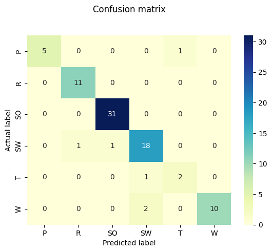

```python
p = sns.heatmap(pd.DataFrame(cm), annot=True,xticklabels=target_names, yticklabels=target_names, cmap="YlGnBu" ,fmt='g')
plt.title('Confusion matrix', y=1.1)
plt.ylabel('Actual label')
plt.xlabel('Predicted label')
```

# **Classification Report**

### **True Positive Rate**

number of samples actually and predicted as `Positive` / total number of samples actually `Positive`  
Also called **Sensitivity or Recall**.

[figure not shown]

### **Positive Predictive Value**

number of samples actually and predicted as `Positive` / total number of samples predicted as `Positive`  
Also called **Precision**.

[figure not shown]

### **F1 score**

Harmonic Mean of Precision and Recall.

[figure not shown]

```python
#import classification_report
from sklearn.metrics import classification_report
print(classification_report(y_true,y_pred, target_names = target_names))
```

```
              precision    recall  f1-score   support

           P       1.00      0.83      0.91         6
           R       0.92      1.00      0.96        11
          SO       0.97      1.00      0.98        31
          SW       0.86      0.90      0.88        20
           T       0.67      0.67      0.67         3
           W       1.00      0.83      0.91        12

    accuracy                           0.93        83
   macro avg       0.90      0.87      0.88        83
weighted avg       0.93      0.93      0.93        83
```

# **ROC curve**

```
3/3 ━━━━━━━━━━━━━━━━━━━━ 0s 10ms/step
```

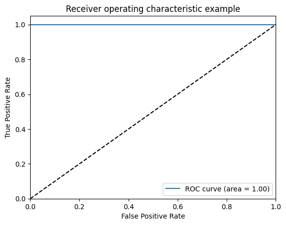

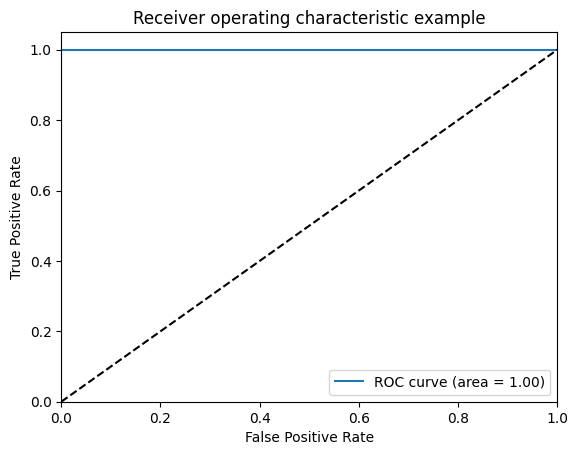

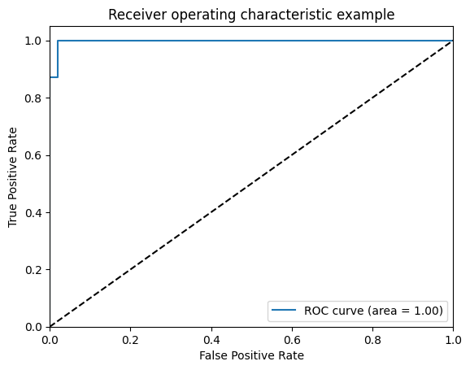

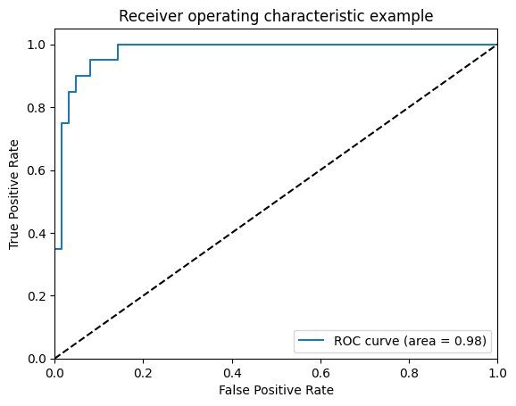

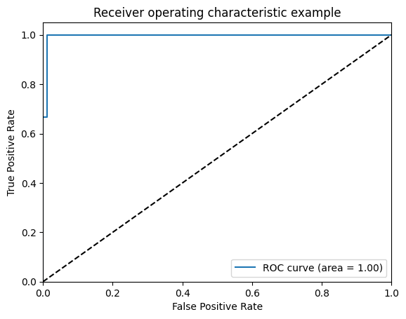

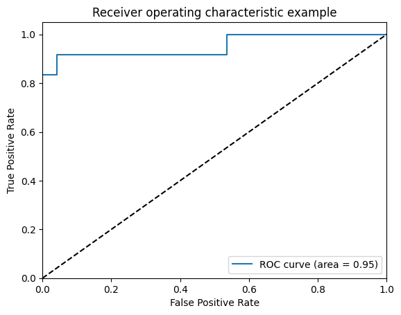

```python
from sklearn.metrics import roc_curve, auc
from itertools import cycle
import numpy as np

from tensorflow.keras.utils import to_categorical
y_test = to_categorical(y_test, num_classes=6)
pred = classifier.predict(X_test)


fpr = dict()
tpr = dict()
roc_auc = dict()
for i in range(6):
    fpr[i], tpr[i], _ = roc_curve(y_test[:, i], pred[:, i])
    roc_auc[i] = auc(fpr[i], tpr[i])

# Plot of a ROC curve for a specific class
for i in range(6):
    plt.figure()
    plt.plot(fpr[i], tpr[i], label='ROC curve (area = %0.2f)' % roc_auc[i])
    plt.plot([0, 1], [0, 1], 'k--')
    plt.xlim([0.0, 1.0])
    plt.ylim([0.0, 1.05])
    plt.xlabel('False Positive Rate')
    plt.ylabel('True Positive Rate')
    plt.title('Receiver operating characteristic example')
    plt.legend(loc="lower right")
    plt.show()
```

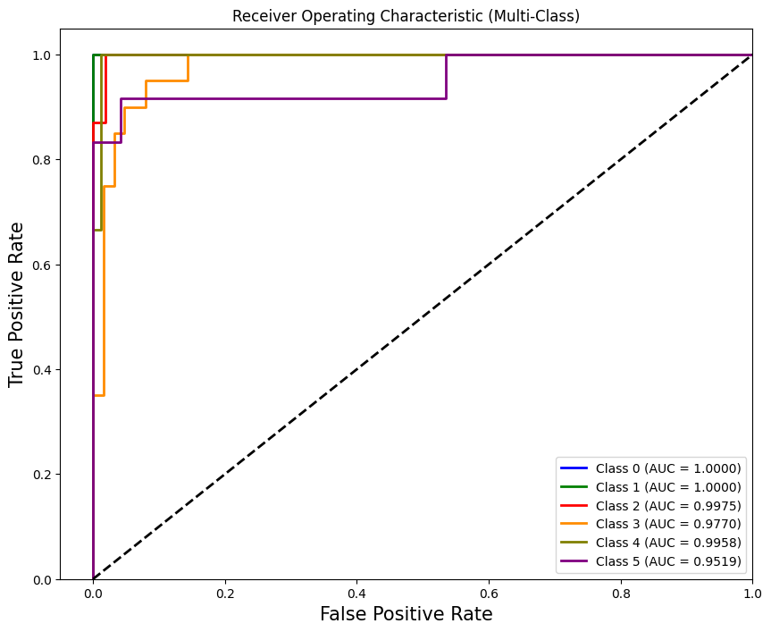

```python
import matplotlib.pyplot as plt
from sklearn.metrics import roc_curve, auc
from sklearn.preprocessing import label_binarize
from itertools import cycle
import numpy as np

# 1. Convert y_test (integers) into a 6-column binary matrix
# Change classes=[0,1,2,3,4,5] if your class IDs are different
y_test_bin = label_binarize(y_test, classes=[0, 1, 2, 3, 4, 5])

# 2. Setup variables
fpr = dict()
tpr = dict()
roc_auc = dict()
lw = 2
n_classes = 6

# 3. Calculate ROC for each class
for i in range(n_classes):
    # Use y_test_bin instead of y_test
    fpr[i], tpr[i], _ = roc_curve(y_test_bin[:, i], pred[:, i])
    roc_auc[i] = auc(fpr[i], tpr[i])

# 4. Plot
colors = cycle(['blue', 'green', 'red', 'darkorange', 'olive', 'purple'])
plt.figure(figsize=(10, 8)) # Optional: make the plot larger

for i, color in zip(range(n_classes), colors):
    plt.plot(fpr[i], tpr[i], color=color, lw=lw,
             label='Class {0} (AUC = {1:0.4f})'.format(i, roc_auc[i]))

plt.plot([0, 1], [0, 1], 'k--', lw=lw)
plt.xlim([-0.05, 1.0])
plt.ylim([0.0, 1.05])
plt.xlabel('False Positive Rate', fontsize=15)
plt.ylabel('True Positive Rate', fontsize=15)
plt.title('Receiver Operating Characteristic (Multi-Class)')
plt.legend(loc="lower right")
plt.show()
```

# **Finetuing the Network**

```python
'''from scikeras.wrappers import KerasClassifier
from sklearn.model_selection import GridSearchCV
from keras.models import Sequential
from keras.layers import Dense, Input

def build_classifier(optimizer='adam'):
    classifier = Sequential()

    # Input Layer
    classifier.add(Input(shape=(10,)))

    # Hidden Layers
    classifier.add(Dense(units=8, kernel_initializer='uniform', activation='relu'))
    classifier.add(Dense(units=16, kernel_initializer='uniform', activation='relu'))
    classifier.add(Dense(units=32, kernel_initializer='uniform', activation='relu'))

    # Output Layer
    classifier.add(Dense(units=6, kernel_initializer='uniform', activation='softmax'))

    # FIX IS HERE: Change loss to 'sparse_categorical_crossentropy'
    classifier.compile(optimizer=optimizer,
                       loss='sparse_categorical_crossentropy',
                       metrics=['accuracy'])
    return classifier

classifier = KerasClassifier(model=build_classifier, verbose=0)

parameters = {
    'batch_size': [16, 32],
    # Note: 800-1000 epochs with CV=10 is extremely slow.
    # Consider reducing for testing (e.g., cv=3, epochs=[50, 100])
    'epochs': [800, 1000],
    'model__optimizer': ['adam', 'rmsprop']
}

grid_search = GridSearchCV(estimator=classifier,
                           param_grid=parameters,
                           scoring='accuracy',
                           cv=10)

print("Training started...")
grid_search = grid_search.fit(X_train, y_train)

best_parameters = grid_search.best_params_
best_accuracy = grid_search.best_score_

print("Best Parameters:", best_parameters)
print("Best Accuracy:", best_accuracy)'''
import tensorflow as tf
tf.config.run_functions_eagerly(True)

import numpy as np
from tensorflow.keras.models import Sequential
from tensorflow.keras.layers import Dense, Input
from tensorflow.keras.optimizers import Adam, RMSprop

X_train = np.asarray(X_train).astype("float32")
y_train = np.asarray(y_train).astype("int32")

def build_model(optimizer_name):
    if optimizer_name == 'adam':
        optimizer = Adam()
    elif optimizer_name == 'rmsprop':
        optimizer = RMSprop()

    model = Sequential()
    model.add(Input(shape=(10,)))
    model.add(Dense(8, activation='relu'))
    model.add(Dense(16, activation='relu'))
    model.add(Dense(32, activation='relu'))
    model.add(Dense(6, activation='softmax'))

    model.compile(
        optimizer=optimizer,
        loss='sparse_categorical_crossentropy',
        metrics=['accuracy']
    )
    return model

optimizers = ['adam', 'rmsprop']
batch_sizes = [16, 32]
epochs_list = [50, 100]

best_acc = 0
best_params = None

for opt in optimizers:
    for bs in batch_sizes:
        for ep in epochs_list:
            print(f"Training → opt={opt}, batch={bs}, epochs={ep}")

            model = build_model(opt)  # 🔥 NEW optimizer every time

            history = model.fit(
                X_train,
                y_train,
                batch_size=bs,
                epochs=ep,
                validation_split=0.2,
                verbose=0
            )

            acc = max(history.history['val_accuracy'])
            if acc > best_acc:
                best_acc = acc
                best_params = (opt, bs, ep)

print("Best Params:", best_params)
print("Best Validation Accuracy:", best_acc)
```

```
Training → opt=adam, batch=16, epochs=50
```

```
Training → opt=adam, batch=16, epochs=100
Training → opt=adam, batch=32, epochs=50
Training → opt=adam, batch=32, epochs=100
Training → opt=rmsprop, batch=16, epochs=50
Training → opt=rmsprop, batch=16, epochs=100
Training → opt=rmsprop, batch=32, epochs=50
Training → opt=rmsprop, batch=32, epochs=100
Best Params: ('adam', 32, 100)
Best Validation Accuracy: 0.8484848737716675
```